# Lab 1: NYT API

Charlie Curtin

2024-04-03

## Lab 1: NYT API

1. Create a free New York Times account (https://developer.nytimes.com/get-started)
2. Pick an interesting environmental key word(s) and use the {jsonlite} package to query the API. Pick something high profile enough and over a large enough time frame that your query yields enough articles for an interesting examination.
3. Recreate the publications per day and word frequency plots using the first paragraph field. This time filter on the response.docs.news_desk variable to winnow out irrelevant results.
- Make some (at least 3) transformations to the corpus including: add context-specific stopword(s), stem a key term and its variants, remove numbers)
4. Recreate the publications per day and word frequency plots using the headlines variable (response.docs.headline.main). Compare the distributions of word frequencies between the first paragraph and headlines. Do you see any difference?

#### Constructing our search term

I picked “snowpack” for my environmental keyword, and my search period is between January 1st, 2020, and April 1st, 2023.

```r
term <- "snowpack"
begin_date <- "20200101"
end_date <- "20230401"

#construct the query url using API operators
baseurl <- paste0("http://api.nytimes.com/svc/search/v2/articlesearch.json?q=",
                  term, "%20",
                  "&begin_date=", begin_date,
                  "&end_date=", end_date,
                  "&facet_filter=true",
                  "&api-key=", API_KEY)
```

```r
# run initial query
initialQuery <- fromJSON(baseurl)

# set the maximum number of pages to grab for articles
maxPages <- 10

# initiate a list to hold results of our for loop
pages <- list()

# for loop
for(i in 0:maxPages){
  nytSearch <- fromJSON(paste0(baseurl, "&page=",i), flatten = TRUE) %>% data.frame()
  message("Retrieving page ", i)
  pages[[i+1]] <- nytSearch
  Sys.sleep(12)
}
```

#### Explore the data we retrieved

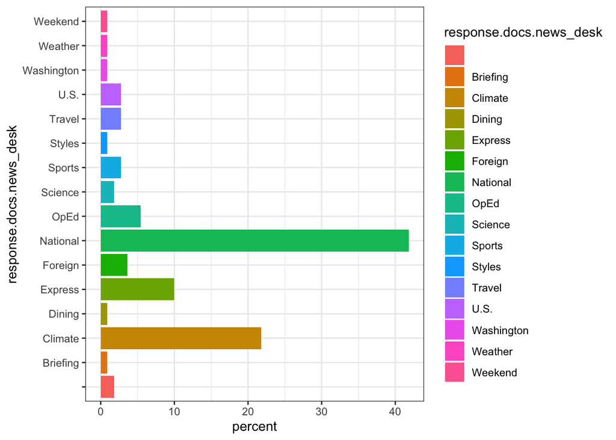

```r
# bind the pages and create a tibble from what the API retrieved
nyt_df <- bind_rows(pages)

# create a bar chart showing what section of the New York Times the piece of media came from
nyt_df %>%
  group_by(response.docs.news_desk) %>%
  summarize(count=n()) %>% #This creates a new data frame with the count of records for each type_of_material.
  mutate(percent = (count / sum(count))*100) %>% #add percent of total column
  ggplot() +
  geom_bar(aes(y=percent, x=response.docs.news_desk, fill=response.docs.news_desk), stat = "identity") +
  theme_bw() +
  coord_flip()
```

- The media relating to snowpack comes from a number of different news desks. I am going to pick media from what I believe to be the most relevant, which are “National”, “Climate”, and “Science”.

#### Publications per day

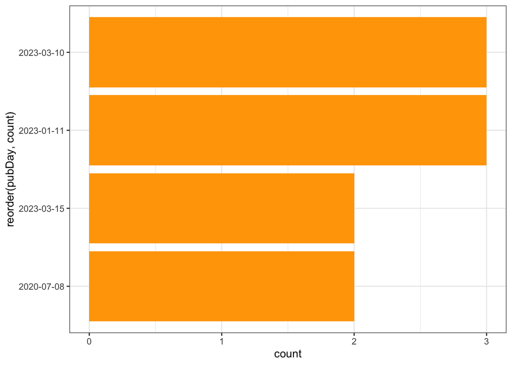

```r
# filter for articles from relevant news desk sources
nyt_df_sub <- nyt_df %>%
  filter(response.docs.news_desk %in% c("National", "Climate", "Science"))

# plot the publications per day
nyt_df_sub %>%
  mutate(pubDay=gsub("T.*","",response.docs.pub_date)) %>%
  group_by(pubDay) %>%
  summarise(count=n()) %>%
  filter(count >= 2) %>%
  ggplot() +
  geom_bar(aes(x=reorder(pubDay, count), y=count),
           fill = "orange",
           stat="identity") +
  theme_bw() +
  coord_flip() #bring date so bars go lengthwise
```

- When we filter for our 3 news desks, we’re still left with 72 articles. We can see that on March 10 and January 11, 2023, there were 3 articles published relating to snowpack

#### Word frequency plots

- To analyze word frequency, we first need to retrieve the first paragraph of each article to gather our text data. By unnesting tokens, we can create a new dataframe where each row is associated with a single word. The dataframe is comprised of every word from the lead paragraphs of all 72 of our articles. We want to filter out stop words, or common words that don’t add to the meaning or sentiment of our text data.

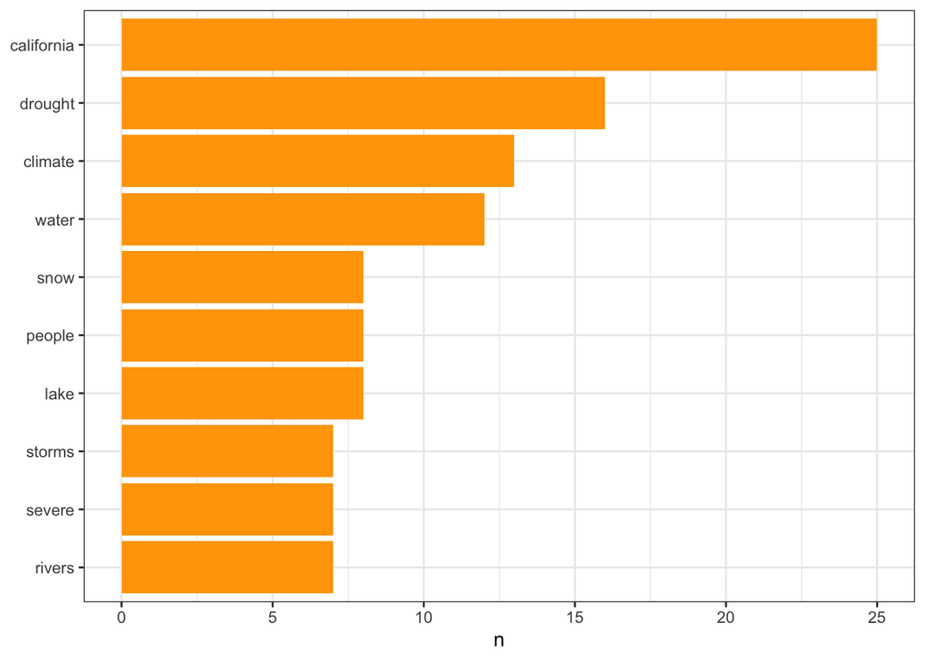

```r
# load stop words from tidytext
data(stop_words)

# create new dataframe that includes every token
tokenized <- nyt_df_sub %>%
  unnest_tokens(word, response.docs.lead_paragraph) %>%  # word is the new column, paragraph is the source
  anti_join(stop_words) # anti_join to only include words that aren't stop words

# plot the top 10 most frequent keywords
tokenized %>%
  count(word, sort = TRUE) %>%
  slice_head(n = 10) %>%
  mutate(word = reorder(word, n)) %>%
  ggplot(aes(n, word)) +
  geom_col(fill = "orange") +
  theme_bw() +
  labs(y = NULL)
```

- We see that the most frequent word is California, and other frequent words relate to storms, snow, or environmental conditions. We can do some more transformations on our tokens and see how the frequencies changes

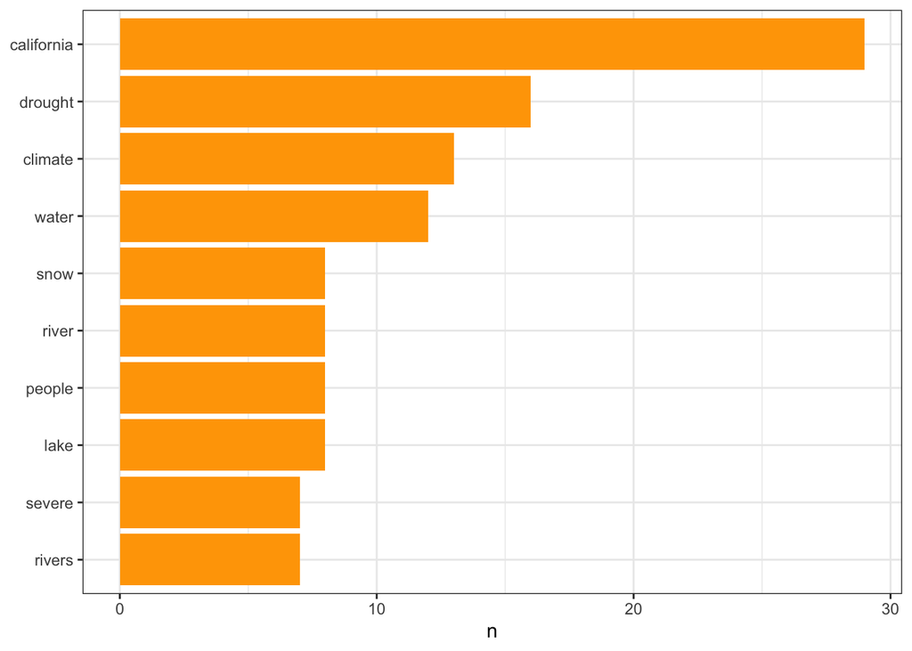

```r
tokenized_sub <- tokenized

# remove "'s" to just get certain root words
tokenized_sub$word <- gsub("’s", '', tokenized_sub$word)

# remove numbers
tokenized_sub$word <- str_remove_all(tokenized_sub$word, "[:digit:]")

# remove empty rows
tokenized_sub <- tokenized_sub %>%
  filter(word != "")

# plot word frequency again
tokenized_sub %>%
  count(word, sort = TRUE) %>%
  slice_head(n = 10) %>%
  mutate(word = reorder(word, n)) %>%
  ggplot(aes(n, word)) +
  geom_col(fill = "orange") +
  theme_bw() +
  labs(y = NULL)
```

#### Word frequency with headlines

To plot word frequency with headlines, our new tokens are going to be the words from each headline. We’ll still use the same transformations as we did with the lead paragraph tokens

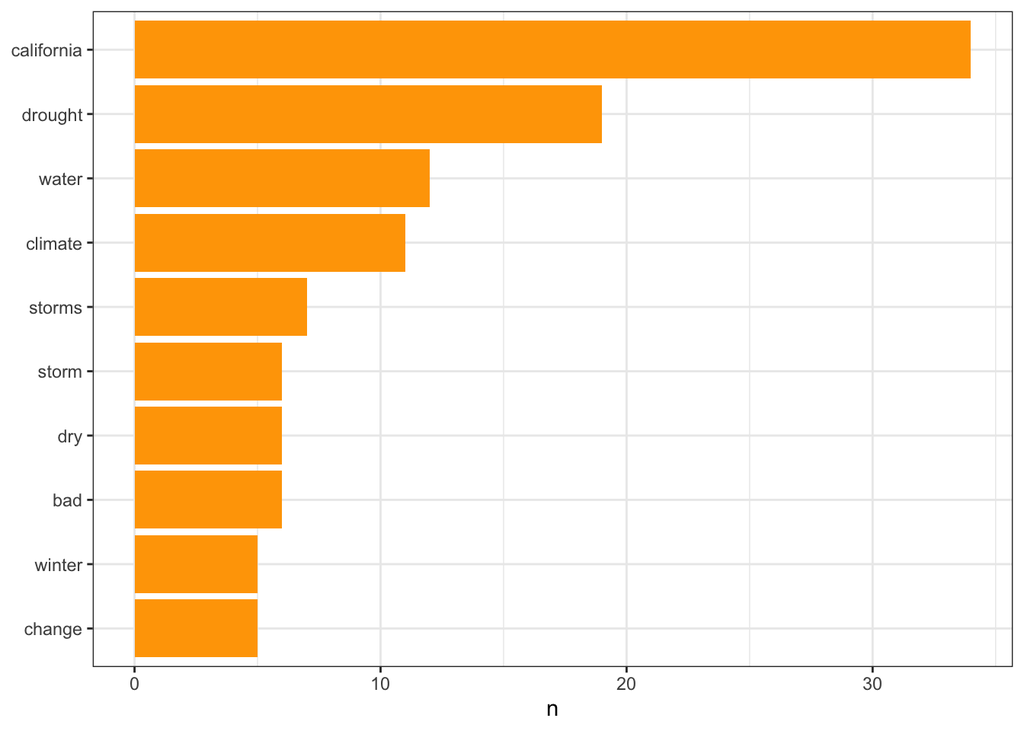

```r
# create new dataframe that includes the tokens from headlines
tokenized_head <- nyt_df_sub %>%
  unnest_tokens(word, response.docs.headline.main) %>%  # word is the new column, paragraph is the source
  anti_join(stop_words)
# create a copy of our headline tokens
words_head <- tokenized_head

# remove "'s" to just get certain root words
words_head$word <- gsub("’s", '', words_head$word)

# remove numbers
words_head$word <- str_remove_all(words_head$word, "[:digit:]")

# remove empty rows
words_head <- words_head %>%
  filter(word != "")

# plot frequency with tokens from headlines
words_head %>%
  count(word, sort = TRUE) %>%
  slice_head(n = 10) %>%
  mutate(word = reorder(word, n)) %>%
  ggplot(aes(n, word)) +
  geom_col(fill = "orange") +
  theme_bw() +
  labs(y = NULL)
```

- Our two most frequent words are still California and drought, and our top 10 words from headlines and lead paragraphs share many similar words. Since we have a different total number of tokens from headlines and lead paragraphs, we need to find the percentage occurrence of the words to directly compare the text from each group

#### Comparing headline text and lead paragraph text

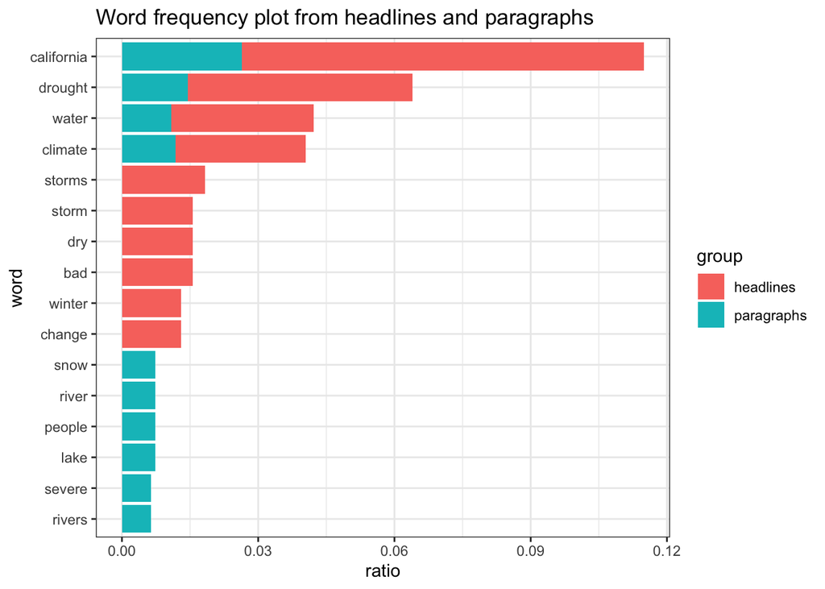

```r
# create new dataframes of percentages of each word
headlines <- words_head %>%
  count(word, sort = TRUE) %>% # get counts of each word
  slice_head(n = 10) %>% # grab the top 10 most frequent words
  mutate(ratio = n / nrow(words_head)) %>% # find the percentage that the word occurred from the total amount of all tokens
  mutate(group = "headlines") # assign a new column with the group

paragraphs <- tokenized_sub %>%
  count(word, sort = TRUE) %>%
  slice_head(n = 10) %>%
  mutate(ratio = n / nrow(tokenized_sub)) %>%
  mutate(group = "paragraphs")

# bind the two dataframes together
tokens_compare <- rbind(headlines, paragraphs)

# plot a bar chart of word frequency
ggplot(tokens_compare) +
  geom_col(aes(x = ratio, y = reorder(word, ratio), fill = group)) +
  theme_bw() +
  labs(y = "word", title = "Word frequency plot from headlines and paragraphs")
```

- We see that our bodies of text from the headlines and lead paragraphs share four of the most common words: California, drought, water, and climate. When accounting for share, all of our most common words for headlines are proportionally more common in headlines that in paragraphs.